# HW11 networks from RFID data

# Goals:

1. Practice examples of how to convert RFID data into social networks
2. Gain more experience with loops
3. Compare different time thresholds for defining whether penguins are “associated”
4. Summarize results and print as a fancy table

## Load packages

```r
library(tidyverse)
```

```r
library(igraph)
library(scales)
library(lubridate)
library(reshape2)
```

## Import data (this is a new dataset, you’ll need to download it and import into your project)

```r
penguingame <- read_csv("Penguin game Little Blue RFID.csv")
glimpse(penguingame)
```

```
## Rows: 168
## Columns: 4
## $ Antenna <chr> "B", "C", "C", "C", "E", "E", "F", "H", "D", "B", "C", "D", "D…
## $ Date    <date> 2021-09-10, 2021-09-10, 2021-09-10, 2021-09-10, 2021-09-10, 2…
## $ Time    <time> 12:53:52, 12:53:52, 12:54:00, 12:54:00, 12:54:00, 12:54:00, 1…
## $ Penguin <chr> "Bowie", "Nugget", "Apple", "Toast", "Cookie", "Nugget", "Mang…
```

```r
#see unique penguins
unique(penguingame$Penguin)
```

```
## [1] "Bowie"  "Nugget" "Apple"  "Toast"  "Cookie" "Mango"
```

```r
#how many penguins?
length(unique(penguingame$Penguin))
```

```
## [1] 6
```

```r
#see unique antennas
unique(penguingame$Antenna)
```

```
## [1] "B" "C" "E" "F" "H" "D" "A"
```

```r
#how many antennas?
length(unique(penguingame$Antenna))
```

```
## [1] 7
```

# How to convert RFID reads to “potential associations”

## Round time

see for custom rounding function: https://stat.ethz.ch/pipermail/r-help/2009-August/401258.html see for sprintf: https://www.rdocumentation.org/packages/base/versions/3.6.2/topics/sprintf

```r
# split of each part of the time
penguingame$hour <- lubridate::hour(penguingame$Time)
penguingame$minute <- lubridate::minute(penguingame$Time)
penguingame$second <- lubridate::second(penguingame$Time)

head(penguingame)
```

```
## # A tibble: 6 × 7
##   Antenna Date       Time     Penguin  hour minute second
##   <chr>   <date>     <time>   <chr>   <int>  <int>  <dbl>
## 1 B       2021-09-10 12:53:52 Bowie      12     53     52
## 2 C       2021-09-10 12:53:52 Nugget     12     53     52
## 3 C       2021-09-10 12:54:00 Apple      12     54      0
## 4 C       2021-09-10 12:54:00 Toast      12     54      0
## 5 E       2021-09-10 12:54:00 Cookie     12     54      0
## 6 E       2021-09-10 12:54:00 Nugget     12     54      0
```

```r
# custom rounding function
mround <- function(x,base){
  base*round(x/base)
}

# round seconds to nearest 5 seconds
penguingame$time.round5sec <- mround(penguingame$second, 5)

# force two digits to display
penguingame$time.round5sec <- sprintf("%02d", penguingame$time.round5sec)

# add a key with hour, minute, second, and antennaID
penguingame$groupKEY.5sec <- paste(penguingame$Date,
                                paste(penguingame$hour,
                                      penguingame$minute,
                                      penguingame$time.round5sec,
                                      sep=":"),
                              penguingame$Antenna,
                              sep="_")

#check
head(penguingame)
```

```
## # A tibble: 6 × 9
##   Antenna Date       Time     Penguin  hour minute second time.round5sec
##   <chr>   <date>     <time>   <chr>   <int>  <int>  <dbl> <chr>
## 1 B       2021-09-10 12:53:52 Bowie      12     53     52 50
## 2 C       2021-09-10 12:53:52 Nugget     12     53     52 50
## 3 C       2021-09-10 12:54:00 Apple      12     54      0 00
## 4 C       2021-09-10 12:54:00 Toast      12     54      0 00
## 5 E       2021-09-10 12:54:00 Cookie     12     54      0 00
## 6 E       2021-09-10 12:54:00 Nugget     12     54      0 00
## # … with 1 more variable: groupKEY.5sec <chr>
```

## Count number of times each penguin is at each antenna at each time using the groupKEY, then add whether each penguin is “present”

### For time rounded to every 5 seconds

```r
ct.penguinXkey.5sec <- penguingame %>%
                          group_by(Penguin, groupKEY.5sec) %>%
                          summarize(count.pings=n())
# add a column that is just "present" (1) at each time interval at each antenna
ct.penguinXkey.5sec$present <- 1

presence.penguinXkey.5sec <- unique(ct.penguinXkey.5sec[c("Penguin", "groupKEY.5sec", "present")])

#check
head(presence.penguinXkey.5sec)
```

```
## # A tibble: 6 × 3
## # Groups:   Penguin [1]
##   Penguin groupKEY.5sec         present
##   <chr>   <chr>                   <dbl>
## 1 Apple   2021-09-10_12:54:00_C       1
## 2 Apple   2021-09-10_12:54:15_H       1
## 3 Apple   2021-09-10_12:54:30_D       1
## 4 Apple   2021-09-10_12:54:50_H       1
## 5 Apple   2021-09-10_12:54:55_A       1
## 6 Apple   2021-09-10_12:55:00_E       1
```

## Reshape the data into individual X group format

```r
indivXgrp.5sec <- reshape2::dcast(presence.penguinXkey.5sec, Penguin~groupKEY.5sec)
head(indivXgrp.5sec)
```

```
##   Penguin 2021-09-10_12:53:50_B 2021-09-10_12:53:50_C 2021-09-10_12:54:00_C
## 1   Apple                    NA                    NA                     1
## 2   Bowie                     1                    NA                    NA
## 3  Cookie                    NA                    NA                    NA
## 4   Mango                    NA                    NA                    NA
## 5  Nugget                    NA                     1                    NA
## 6   Toast                    NA                    NA                     1
##   2021-09-10_12:54:00_E 2021-09-10_12:54:15_F 2021-09-10_12:54:15_H
## 1                    NA                    NA                     1
## 2                    NA                    NA                    NA
## 3                     1                    NA                    NA
## 4                    NA                     1                    NA
## 5                     1                    NA                    NA
## 6                    NA                    NA                    NA
##   2021-09-10_12:54:30_D 2021-09-10_12:54:35_B 2021-09-10_12:54:35_C
```

[output cut: 279 more lines]

```r
# convert to matrix format using matrix.please function
matrix.please <- function(x) {
  m<-as.matrix(x[,-1])
  rownames(m)<-x[,1]
  m
}

indivXgrp.5sec.mx <- matrix.please(indivXgrp.5sec)
indivXgrp.5sec.mx[is.na(indivXgrp.5sec.mx)] <- 0
```

## Project the data to show the number of times each penguin is seen at the same time and place (antennaID) as others

https://dshizuka.github.io/networkanalysis/02_dataformats.html:

"There are different ways to convert this data into a social network–i.e., a network that describes which individual co-occurs with which individual in groups. One simple way is to do what is called a one-mode projection of this data by multiplying this matrix with the transpose of itself. Note that matrix multiplication notation is %*% in R."

“This resulting matrix is now an adjacency matrix in which the diagonal represents how many groups each individual participated in (2 for all of them), and the off-diagonals represent the number of times a pair of individuals were in the same group.”

```r
penguinXpenguin.5sec <- indivXgrp.5sec.mx %*% t(indivXgrp.5sec.mx)
```

## Convert to network object and plot

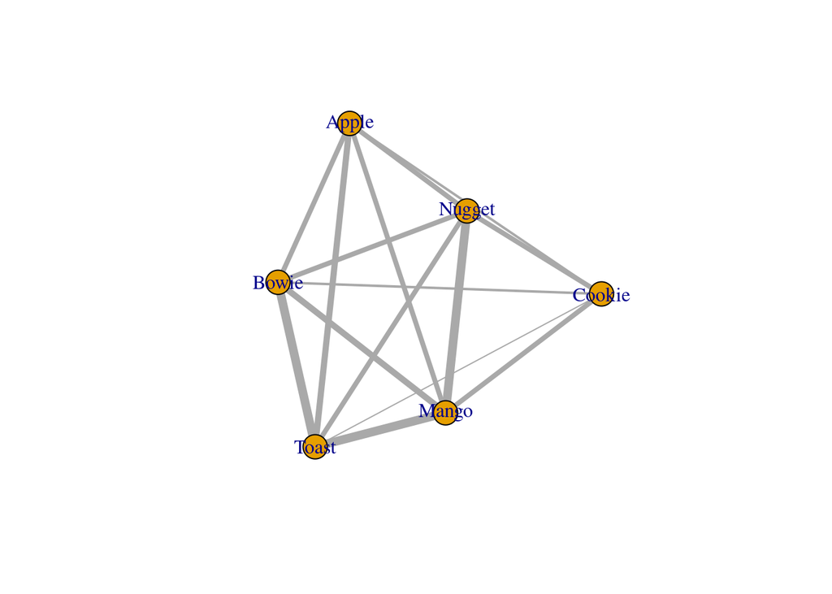

```r
game5sec.net <- igraph::graph_from_adjacency_matrix(penguinXpenguin.5sec, "undirected", weighted=TRUE, diag=FALSE)
plot(game5sec.net, edge.width=E(game5sec.net)$weight)
```

## Pretty up the plot

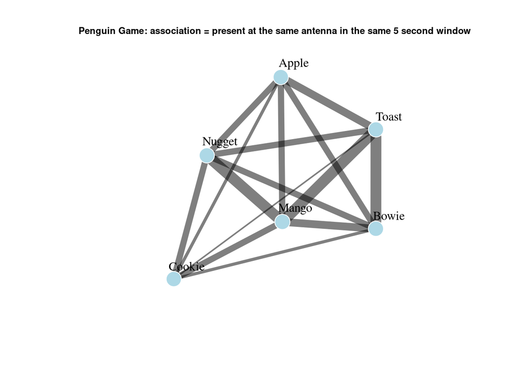

```r
# plot
set.seed(42)
plot(game5sec.net,

  #format nodes
  vertex.color="lightblue", #node fill color
  vertex.frame.color="white", #node outline color

  #format edges
  edge.color=alpha("black", 0.5), #edge color
  edge.width=E(game5sec.net)$weight*2, #width of edges

  #format labels
  vertex.label.cex=1, #font size of labels
  vertex.label.color="black", #font color
  vertex.label.dist=2.5, #moves label away from node center
)
# add title
title("Penguin Game: association = present at the same antenna in the same 5 second window", cex.main=0.75)
```

# What if we want to look at the effect of different thresholds? Let’s write a loop!

## Set up for the loop

```r
#set up the "guide" for your loop
guide <- c(2, 5, 10) # here we'll look at 3 thresholds

#set up your empty dataframe (where you will store all the data from your loop)
net.summary <- data.frame(rounding.scheme = character(),
                          penguin = character(),
                          degree = numeric(),
                          strength = numeric())

#import data again
penguingame.new <- read_csv("Penguin game Little Blue RFID.csv")
#extract the parts of the times (just like earlier)
penguingame.new$hour <- lubridate::hour(penguingame.new$Time)
penguingame.new$minute <- lubridate::minute(penguingame.new$Time)
penguingame.new$second <- lubridate::second(penguingame.new$Time)
```

### LOOP!

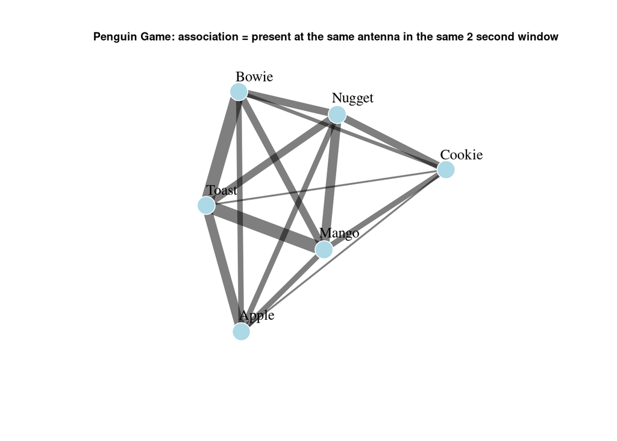

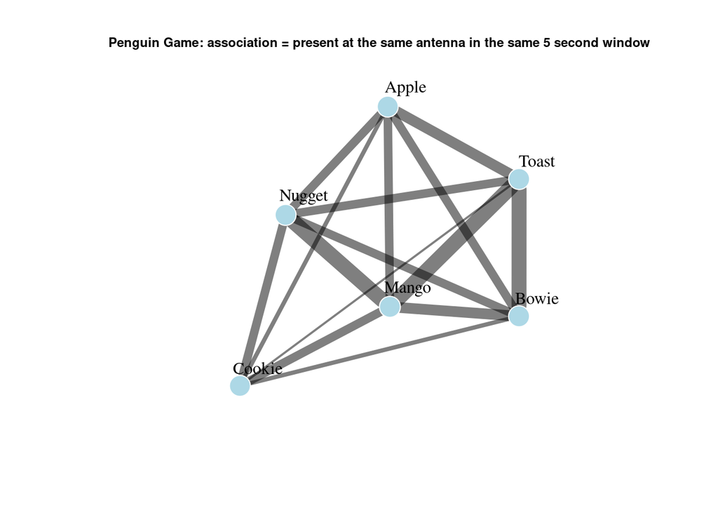

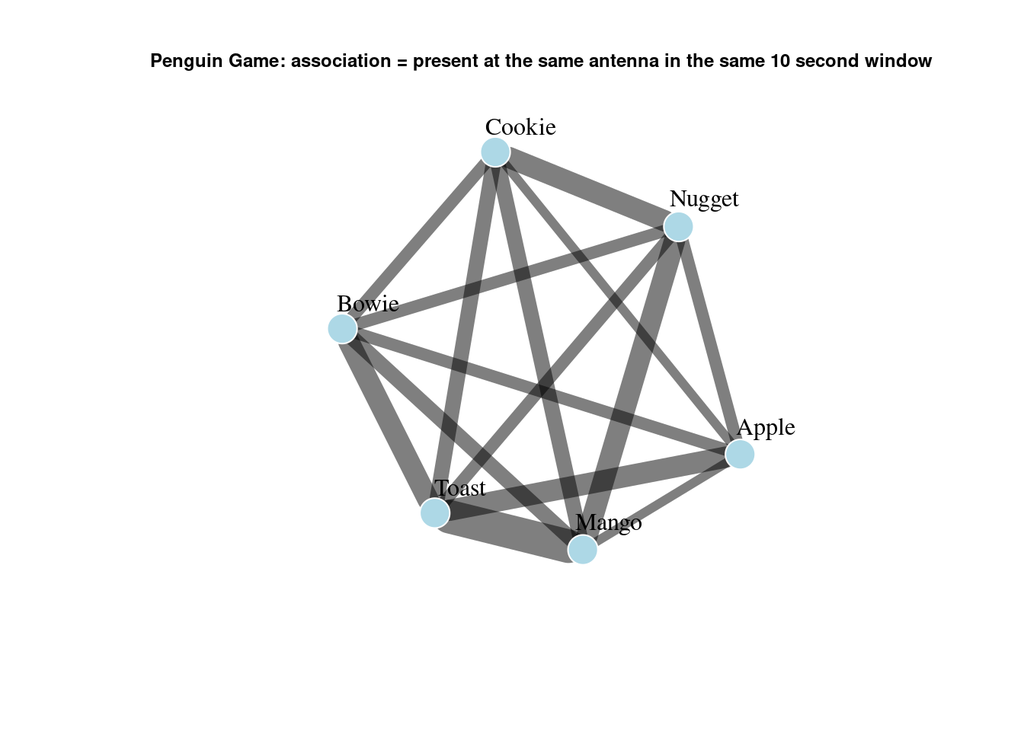

```r
for (net in 1:length(guide)) {
  #net=1
  loop.round <- guide[net] #what are we rounding by for this loop?

  #rename data for loop
  loop.data <- penguingame.new

  # split of each part of the time, rounding by whatever is in loop.round
  loop.data$sec.rounded <- mround(loop.data$second, loop.round)

  # force two digits to display
  loop.data$sec.rounded <- sprintf("%02d", loop.data$sec.rounded)

  # add a key with hour, minute, second, and antennaID
  loop.data$groupKEY <- paste(loop.data$Date,
                                  paste(loop.data$hour,
                                        loop.data$minute,
                                        loop.data$sec.rounded,
                                        sep=":"),
                                loop.data$Antenna,
                                sep="_")

  # summarize
  ct.penguinXkey <- loop.data %>%
                          group_by(Penguin, groupKEY) %>%
                          summarize(count.pings=n())

  # add a column that is just "present" (1) at each time interval at each antenna
  ct.penguinXkey$present <- 1

  # extract all unique rows
  presence.penguinXkey <- unique(ct.penguinXkey[c("Penguin", "groupKEY", "present")])

  #check
  #head(presence.penguinXkey)

  #make penguin by group dataframe then convert to a matrix
  indivXgrp <- reshape2::dcast(presence.penguinXkey, Penguin~groupKEY)
  indivXgrp.mx <- matrix.please(indivXgrp) # make into matrix
  indivXgrp.mx[is.na(indivXgrp.mx)] <- 0  # set any NA cells to 0

  #multiple matrix by transpose to get penguin by penguin matrix
  penguinXpenguin <- indivXgrp.mx %*% t(indivXgrp.mx)

  #convert to network object
  game.net <- igraph::graph_from_adjacency_matrix(penguinXpenguin, "undirected", weighted=TRUE, diag=FALSE)

  #plot
# plot
  set.seed(42)
  plot(game.net,

    #format nodes
    vertex.color="lightblue", #node fill color
    vertex.frame.color="white", #node outline color

    #format edges
    edge.color=alpha("black", 0.5), #edge color
    edge.width=E(game.net)$weight*2, #width of edges

    #format labels
    vertex.label.cex=1, #font size of labels
    vertex.label.color="black", #font color
    vertex.label.dist=2.5, #moves label away from node center
  )
  # add title
  title(paste("Penguin Game: association = present at the same antenna in the same", loop.round, "second window", sep=" "), cex.main=0.75)

  # summarize network structure

  #find the density
  edge_density(game.net)

  #find degree
  degree <- degree(game.net)

  #find strength
  strength <- strength(game.net)

  #save penguin degree and strength then write to main dataframe
  penguinID <- names(strength) #make labels for penguins

  rounding.scheme <- rep(loop.round, length(penguinID)) #make labels for rounding scheme

  combo <- cbind.data.frame(penguinID, rounding.scheme, degree, strength) #assemble this loop's data
  rownames(combo) <- NULL #get rid of row names

  net.summary <- rbind.data.frame(net.summary, combo) # save this loop's data to the main dataframe

}
```

## Print out a nice table

We’ll use a new package called kableExtra to make nice tables to show summary data. Nice table reference: https://cran.r-project.org/web/packages/kableExtra/vignettes/awesome_table_in_html.html

```r
# cast data into wider format

net.summary.wide <- reshape2::dcast(net.summary, penguinID~rounding.scheme)
colnames(net.summary.wide) <- c("penguinID", "strength.2sec", "strength.5sec", "strength.10sec")

library(kableExtra)
#basic table
net.summary.wide %>%
  kbl() %>%
  kable_styling()
```

| penguinID | strength.2sec | strength.5sec | strength.10sec |
| --- | --- | --- | --- |
| Apple | 15 | 19 | 21 |
| Bowie | 20 | 22 | 24 |
| Cookie | 11 | 13 | 24 |
| Mango | 22 | 27 | 31 |
| Nugget | 20 | 23 | 26 |
| Toast | 24 | 24 | 34 |

```r
#different format
net.summary.wide %>%
  kbl() %>%
  kable_classic_2(full_width=FALSE)
```

| penguinID | strength.2sec | strength.5sec | strength.10sec |
| --- | --- | --- | --- |
| Apple | 15 | 19 | 21 |
| Bowie | 20 | 22 | 24 |
| Cookie | 11 | 13 | 24 |
| Mango | 22 | 27 | 31 |
| Nugget | 20 | 23 | 26 |
| Toast | 24 | 24 | 34 |

```r
# color code cells in the table based on their values
net.summary.wide %>%
  kbl() %>%
  kable_classic_2(full_width=FALSE) %>%
  #set up column #2, strength with 2 sec network
  column_spec(2, color="white",
              background=spec_color(net.summary.wide$strength.2sec[1:6], end=1)) %>%
  #set up column #3, strength with 5 sec network
  column_spec(3, color="white",
              background=spec_color(net.summary.wide$strength.5sec[1:6], end=1)) %>%
  #set up column #4, strength with 10 sec network
  column_spec(4, color="white",
              background=spec_color(net.summary.wide$strength.10sec[1:6], end=1))
```

| penguinID | strength.2sec | strength.5sec | strength.10sec |
| --- | --- | --- | --- |
| Apple | 15 | 19 | 21 |
| Bowie | 20 | 22 | 24 |
| Cookie | 11 | 13 | 24 |
| Mango | 22 | 27 | 31 |
| Nugget | 20 | 23 | 26 |
| Toast | 24 | 24 | 34 |

#TOKEN CHALLENGE: Write out all the steps we used to process the RFID data and make the network